# EasyVisa Project

### XGB Boosting Tuning

```python
# Choose the type of classifier.
xgb_tuned = XGBClassifier(random_state=1, eval_metric='logloss')

# Grid of parameters to choose from
parameters = {
    "n_estimators": [10,30,50],
    "scale_pos_weight":[1,2,5],
    "subsample":[0.7,0.9,1],
    "learning_rate":[0.05, 0.1,0.2],
    "colsample_bytree":[0.7,0.9,1],
    "colsample_bylevel":[0.5,0.7,1]
}

# Type of scoring used to compare parameter combinations
scorer = metrics.make_scorer(metrics.f1_score)

# Run the grid search
grid_obj = GridSearchCV(xgb_tuned, parameters,scoring=scorer,cv=5)
grid_obj = grid_obj.fit(X_train, y_train)

# Set the clf to the best combination of parameters
xgb_tuned = grid_obj.best_estimator_

# Fit the best algorithm to the data.
xgb_tuned.fit(X_train, y_train)
```

```
XGBClassifier(base_score=0.5, booster='gbtree', colsample_bylevel=0.5,
              colsample_bynode=1, colsample_bytree=0.7, eval_metric='logloss',
              gamma=0, gpu_id=-1, importance_type='gain',
              interaction_constraints='', learning_rate=0.05, max_delta_step=0,
              max_depth=6, min_child_weight=1, missing=nan,
              monotone_constraints='()', n_estimators=30, n_jobs=8,
              num_parallel_tree=1, random_state=1, reg_alpha=0, reg_lambda=1,
              scale_pos_weight=1, subsample=1, tree_method='exact',
              validate_parameters=1, verbosity=None)
```

```
Training performance:
    Accuracy    Recall  Precision        F1
0  0.753986  0.908908   0.766331  0.831552
Testing performance:
    Accuracy    Recall  Precision        F1
0  0.744204  0.898255   0.761636  0.824323
```

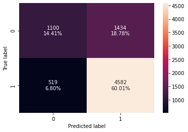

```python
#Calculating different metrics
xgb_tuned_model_train_perf=model_performance_classification_sklearn(xgb_tuned,X_train,y_train)
print("Training performance:\n",xgb_tuned_model_train_perf)
xgb_tuned_model_test_perf=model_performance_classification_sklearn(xgb_tuned,X_test,y_test)
print("Testing performance:\n",xgb_tuned_model_test_perf)

#Creating confusion matrix
confusion_matrix_sklearn(xgb_tuned,X_test,y_test)
```

- Slightly better than non tuned XGB model

```python
estimators = [('Random Forest',rf_tuned), ('Gradient Boosting',gbc_tuned), ('Decision Tree',dtree_estimator)]

final_estimator = xgb_tuned

stacking_classifier= StackingClassifier(estimators=estimators,final_estimator=final_estimator)

stacking_classifier.fit(X_train,y_train)
```

```
StackingClassifier(estimators=[('Random Forest',
                                RandomForestClassifier(class_weight={0: 0.35,
                                                                     1: 0.65},
                                                       max_depth=3,
                                                       max_features=0.6,
                                                       max_samples=0.7,
                                                       n_estimators=90,
                                                       random_state=1)),
                               ('Gradient Boosting',
                                GradientBoostingClassifier(init=AdaBoostClassifier(random_state=1),
                                                           max_features=0.7,
                                                           random_state=1,
                                                           subsample=0.8)),
                               ('Decision Tree',
                                DecisionTreeClassifier...
                                                 eval_metric='logloss', gamma=0,
                                                 gpu_id=-1,
                                                 importance_type='gain',
                                                 interaction_constraints='',
                                                 learning_rate=0.05,
                                                 max_delta_step=0, max_depth=6,
                                                 min_child_weight=1,
                                                 missing=nan,
                                                 monotone_constraints='()',
                                                 n_estimators=30, n_jobs=8,
                                                 num_parallel_tree=1,
                                                 random_state=1, reg_alpha=0,
                                                 reg_lambda=1,
                                                 scale_pos_weight=1,
                                                 subsample=1,
                                                 tree_method='exact',
                                                 validate_parameters=1,
                                                 verbosity=None))
```

```
Training performance:
    Accuracy   Recall  Precision        F1
0  0.754435  0.88437   0.778287  0.827944
Testing performance:
    Accuracy   Recall  Precision        F1
0  0.749967  0.87375   0.778923  0.823616
```

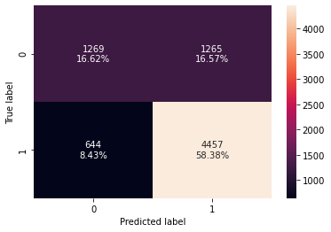

```python
#Calculating different metrics
stacking_classifier_model_train_perf=model_performance_classification_sklearn(stacking_classifier,X_train,y_train)
print("Training performance:\n",stacking_classifier_model_train_perf)
stacking_classifier_model_test_perf=model_performance_classification_sklearn(stacking_classifier,X_test,y_test)
print("Testing performance:\n",stacking_classifier_model_test_perf)

#Creating confusion matrix
confusion_matrix_sklearn(stacking_classifier,X_test,y_test)
```

- Similar performance to the other tuned models

```python
# training performance comparison

models_train_comp_df = pd.concat(
    [dtree_model_train_perf.T,dtree_estimator_model_train_perf.T,rf_estimator_model_train_perf.T,rf_tuned_model_train_perf.T,
     bagging_classifier_model_train_perf.T,bagging_estimator_tuned_model_train_perf.T,ab_classifier_model_train_perf.T,
     abc_tuned_model_train_perf.T,gb_classifier_model_train_perf.T,gbc_tuned_model_train_perf.T,xgb_classifier_model_train_perf.T,
    xgb_tuned_model_train_perf.T,stacking_classifier_model_train_perf.T],
    axis=1,
)
models_train_comp_df.columns = [
    "Decision Tree",
    "Decision Tree Estimator",
    "Random Forest Estimator",
    "Random Forest Tuned",
    "Bagging Classifier",
    "Bagging Estimator Tuned",
    "Adaboost Classifier",
    "Adabosst Classifier Tuned",
    "Gradient Boost Classifier",
    "Gradient Boost Classifier Tuned",
    "XGBoost Classifier",
    "XGBoost Classifier Tuned",
    "Stacking Classifier"]
print("Training performance comparison:")
models_train_comp_df
```

```
Training performance comparison:
```

|  | Decision Tree | Decision Tree Estimator | Random Forest Estimator | Random Forest Tuned | Bagging Classifier | Bagging Estimator Tuned | Adaboost Classifier | Adabosst Classifier Tuned | Gradient Boost Classifier | Gradient Boost Classifier Tuned | XGBoost Classifier | XGBoost Classifier Tuned | Stacking Classifier |
| --- | --- | --- | --- | --- | --- | --- | --- | --- | --- | --- | --- | --- | --- |
| Accuracy | 1.0 | 0.668089 | 1.0 | 0.718561 | 0.984673 | 0.668089 | 0.740568 | 0.745509 | 0.757242 | 0.757018 | 0.832922 | 0.753986 | 0.754435 |
| Recall | 1.0 | 1.000000 | 1.0 | 0.953361 | 0.985882 | 1.000000 | 0.890840 | 0.899160 | 0.880504 | 0.879160 | 0.928151 | 0.908908 | 0.884370 |
| Precision | 1.0 | 0.668089 | 1.0 | 0.717902 | 0.991130 | 0.668089 | 0.761402 | 0.762488 | 0.783109 | 0.783553 | 0.838903 | 0.766331 | 0.778287 |
| F1 | 1.0 | 0.801023 | 1.0 | 0.819045 | 0.988499 | 0.801023 | 0.821051 | 0.825203 | 0.828956 | 0.828608 | 0.881273 | 0.831552 | 0.827944 |

```python
# testing performance comparison

models_test_comp_df = pd.concat(
    [dtree_model_test_perf.T,dtree_estimator_model_test_perf.T,rf_estimator_model_test_perf.T,rf_tuned_model_test_perf.T,
     bagging_classifier_model_test_perf.T,bagging_estimator_tuned_model_test_perf.T,ab_classifier_model_test_perf.T,
     abc_tuned_model_test_perf.T,gb_classifier_model_test_perf.T,gbc_tuned_model_test_perf.T,xgb_classifier_model_test_perf.T,
    xgb_tuned_model_test_perf.T,stacking_classifier_model_test_perf.T],
    axis=1,
)
models_test_comp_df.columns = [
    "Decision Tree",
    "Decision Tree Estimator",
    "Random Forest Estimator",
    "Random Forest Tuned",
    "Bagging Classifier",
    "Bagging Estimator Tuned",
    "Adaboost Classifier",
    "Adabosst Classifier Tuned",
    "Gradient Boost Classifier",
    "Gradient Boost Classifier Tuned",
    "XGBoost Classifier",
    "XGBoost Classifier Tuned",
    "Stacking Classifier"]
print("Testing performance comparison:")
models_test_comp_df
```

```
Testing performance comparison:
```

|  | Decision Tree | Decision Tree Estimator | Random Forest Estimator | Random Forest Tuned | Bagging Classifier | Bagging Estimator Tuned | Adaboost Classifier | Adabosst Classifier Tuned | Gradient Boost Classifier | Gradient Boost Classifier Tuned | XGBoost Classifier | XGBoost Classifier Tuned | Stacking Classifier |
| --- | --- | --- | --- | --- | --- | --- | --- | --- | --- | --- | --- | --- | --- |
| Accuracy | 0.657367 | 0.668107 | 0.721022 | 0.713556 | 0.701244 | 0.668107 | 0.733857 | 0.738441 | 0.747610 | 0.748003 | 0.730452 | 0.744204 | 0.749967 |
| Recall | 0.738287 | 1.000000 | 0.832974 | 0.944717 | 0.779259 | 1.000000 | 0.877475 | 0.888453 | 0.867869 | 0.865517 | 0.851206 | 0.898255 | 0.873750 |
| Precision | 0.746186 | 0.668107 | 0.768771 | 0.716686 | 0.774854 | 0.668107 | 0.760836 | 0.760403 | 0.779401 | 0.781001 | 0.769722 | 0.761636 | 0.778923 |
| F1 | 0.742215 | 0.801036 | 0.799586 | 0.815053 | 0.777050 | 0.801036 | 0.815004 | 0.819456 | 0.821260 | 0.821090 | 0.808416 | 0.824323 | 0.823616 |

- XGB Boosting Classifier Tuned model is giving the best F1 performance and is not severely overfitting the training data.
- Tuned Gradient Boost, and AdaBoost Tuned are also giving similar score.
- Feature importance comparison across XGB Boosting Tuned Classifier, Tuned Gradient Boost and Tuned Adaboost to determine which features make the most sense to emphasize.

## Model Performance Comparison and Conclusions

### Feature Importance of XGB Boosting Tuned Classifier

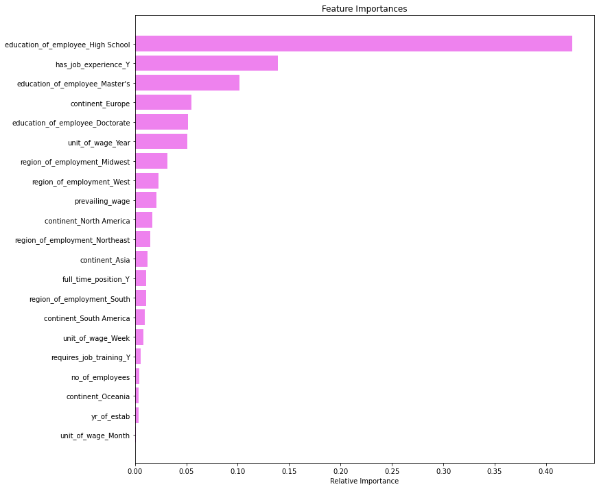

```python
feature_names = X_train.columns
importances = xgb_tuned.feature_importances_
indices = np.argsort(importances)

plt.figure(figsize=(12,12))
plt.title('Feature Importances')
plt.barh(range(len(indices)), importances[indices], color='violet', align='center')
plt.yticks(range(len(indices)), [feature_names[i] for i in indices])
plt.xlabel('Relative Importance')
plt.show()
```

- Having a High School education is the most important feature in the XGB boosting classifier.
- Previous experience is also important in a lower second place impact.
- This model is placing emphasis on having education (emphasizing High School, Master's, Doctorate), having previous work experience, and also coming from Europe.

### Feauture Importance of Gradient Boosting Tuned Classifier

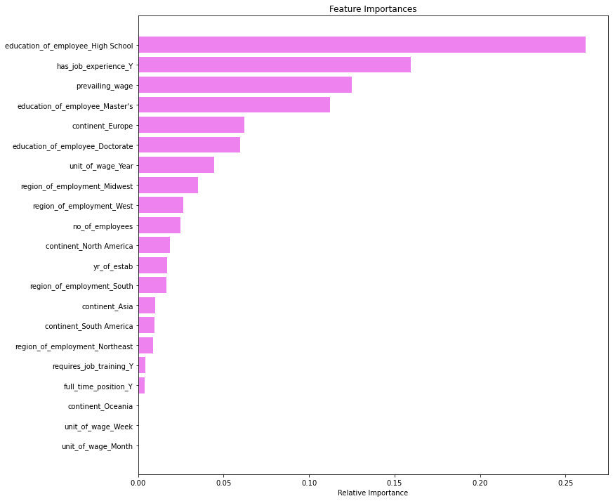

```python
feature_names = X_train.columns
importances = gbc_tuned.feature_importances_
indices = np.argsort(importances)

plt.figure(figsize=(12,12))
plt.title('Feature Importances')
plt.barh(range(len(indices)), importances[indices], color='violet', align='center')
plt.yticks(range(len(indices)), [feature_names[i] for i in indices])
plt.xlabel('Relative Importance')
plt.show()
```

- This model also emphasizes Education of the applicant, previous experience and also prevailing wage of the applicant.
- This model ensures the applicant is getting paid comparatively to other workers at the sponsor company.
- This model also has those coming from Europe as more likely to be certified for a work Visa.

### Feature Importance of Adaboost Tuned Classifier

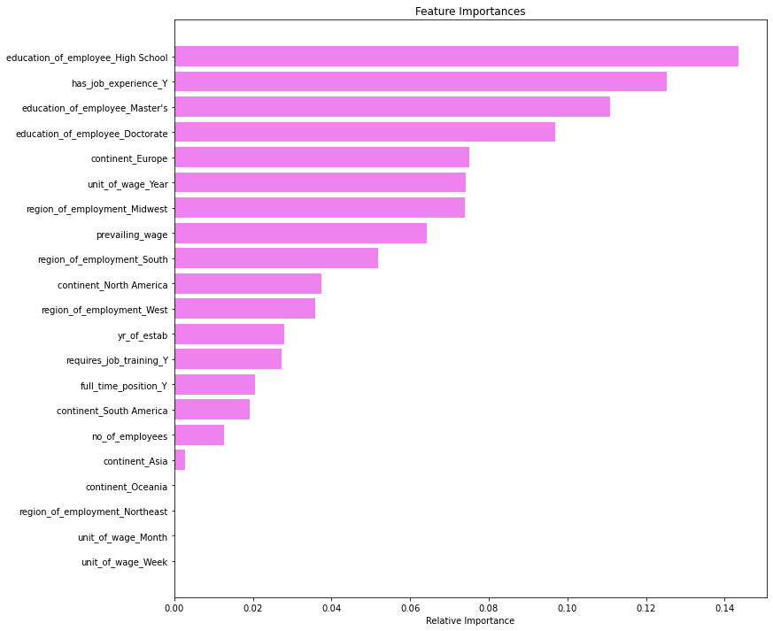

```python
feature_names = X_train.columns
importances = abc_tuned.feature_importances_
indices = np.argsort(importances)

plt.figure(figsize=(12,12))
plt.title('Feature Importances')
plt.barh(range(len(indices)), importances[indices], color='violet', align='center')
plt.yticks(range(len(indices)), [feature_names[i] for i in indices])
plt.xlabel('Relative Importance')
plt.show()
```

- This model is giving the most equally distributed results across multiple features and is not so skewed reliant on High School education like the other models.
- In this model Education (High School, Master's, and Doctorate) and previous work experience are sharing similar importance.
- This model also places emphasis on workers from Europe and North America and employees with salaried work experience, coming from full time work.

## Actionable Insights and Recommendations

- Based on the Adaboost tuned classifier model we can create with reasonable certainty an employee profile.
  - AdaBoost Tuned model predicts roughly 73% correct. The model is correctlly predicting those that should be certified (59%) and correctly identifying those that should not (15%).
  - Employers should look for applicants with at least High School education, but preferably Master's or Doctorate's.
  - Applicants should have previous work experience.
  - Applicants should have been on a yearly pay rate.
  - Applicants from Europe and North America should be prioritized over other geographical areas possibly due to better previous work experience that is transferable to the United States.

### Further Insight

- The model can be improved by gathering more information:
  - Is the education the highest level obtained?
  - Does the previous job experience involve any job experience, or experience that could be used in the new job?
  - Insight into the type of work the employee is trying to get a Visa for; Agriculture, Tech, Manufacturing, Medicine.
  - More information about amounts of pay.
  - Are the applicants male/female?
  - Do the applicants have relatives in the U.S?
  - Age of applicants.